[figure not shown]

# 概述

这个仓库用来实践使用jupyter notebook作为写作平台的方法。  
本文用来描述实践过程中总结的完整方法体系。  
具体内容包括写作环境的搭建及配置、博客写作规范、各类元素的使用方法、将文章转换成展示用的slide方法、部署写作平台的方法等。

# 写作环境

- [jupyter notebook](https://jupyter-notebook.readthedocs.io/en/stable/)
- ipython-contrib/jupyter_contrib_nbextensions

## notebook基础

参考[installation guide](https://jupyter.readthedocs.io/en/latest/install.html#install)进行安装。  
[这里](https://jupyter-notebook.readthedocs.io/en/stable/notebook.html#introduction)介绍了notebook的基本情况。

## notebook扩展

参考[这里](http://jupyter-contrib-nbextensions.readthedocs.io/en/latest/install.html)安装jupyter_contrib_nbextensions。  
安装时主要包括如下三步：

- 安装packages
- 安装js和css文件
- 重启jupyter

[这里](http://jupyter-contrib-nbextensions.readthedocs.io/en/latest/nbextensions.html)介绍了包含的扩展的具体信息。  
推荐使用如下扩展：

- Table of Contents: 用来给文档生成目录
- RISE: 用来生成基于Reveal.js的演示slide

# 博客规范

## 组织

一个文章以一个notebook的形式表现。  
文件系统中创建一个和notebook同名的目录，用来管理notebook中使用的资源。  
文章中只使用相对路径引用此目录下的资源。  
禁止使用绝对路径引用文件系统中的资源。  
减少使用绝对路径引用网络资源，避免一段时间后资源不存在的情况。

## 目录

文章的目录使用Table of Contents插件生成。  
每个notebook都会在开始部分插入一个目录的Cell，方便读者了解文章的大纲。

## 章节

每个章节使用独立的cell。这样编辑时可以做到相对独立编辑特定cell，保持其他cell的渲染状态。

# 元素

## 图片资源

Markdown cell中使用图片引用语法`![Alt Text](Image Path)`。这种方法引用的图片可以直接渲染在结果文档中。可以参考本文的封面图。

## 代码

演示类代码一般需要包含源码和源码执行结果。这个是jupyter notebooks的强项。

## Python代码

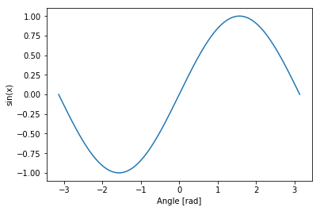

```javascript
import matplotlib.pylab as plt
import numpy as np
x = np.linspace(-np.pi, np.pi, 201)
plt.plot(x, np.sin(x))
plt.xlabel('Angle [rad]')
plt.ylabel('sin(x)')
plt.axis('tight')
plt.show()
```

## node.js代码

```javascript
const fs = require('fs')
fs.stat('./README.ipynb', function(err, stat) {
    console.log(stat);
})
```

```
undefined
```

```
{ dev: 16777221,
  mode: 33188,
  nlink: 1,
  uid: 501,
  gid: 20,
  rdev: 0,
  blksize: 4194304,
  ino: 8616215030,
  size: 31144,
  blocks: 64,
  atime: 2018-07-21T16:33:04.118Z,
  mtime: 2018-07-21T16:32:50.871Z,
  ctime: 2018-07-21T16:32:50.871Z,
  birthtime: 2018-07-20T04:38:08.808Z }
```

# 展示

## Slides视图

使用jupyter notebook可以很方便的生成演示用的slides。  
参考[这里](https://damianavila.github.io/RISE/installation.html)安装RISE扩展。  
安装完成后重启jupyter。  
重新打开jupyter notebook后，可以在工具栏上看到对应按钮：

[figure not shown]

## 静态Slides

Slides视图提供的Slides版本是需要jupyter作为服务器进行host的。RISE提供的生成Slides的功能基于Reveal.js，使用下图所示菜单项

[figure not shown]

将notebook生成可以配合reveal.js使用的html文件。然后将此html文件放在reveal.js同级目录下，打开此html时即可使用生成的静态Slides。

## 自定义

默认皮肤看腻了，可以使用[RISE提供的方法](https://damianavila.github.io/RISE/customize.html)进行自定义。  
目前RISE生成slides的工具有bug，自定义主题的背景色等都是不正确的。

- [ ] 进一步研究RISE生成原理
- [ ] Reveal.js的自定义配置
- [ ] notebook中如何配置Reveal.js

# 发布

## 发布到Github

完成Commit后，直接push到github上对应的Repository，从github上打开对应的notebook时会自动渲染成最终结果。  
如下图所示：

[figure not shown]

## 发布文章

- [ ] 构建静态文章的流程和工程布局
- [ ] 批量生成静态文章的脚本工具

## 发布Slides

- [ ] 构建Slides的流程和工程布局
- [ ] 批量生成静态Slides的脚本工具
- [ ] 接入新的自定义主题
- [ ] 文章和Slides的自动关联